# COVID 19 Data Analysis

2023-05-13

# Introduction:

This is the final project for the Data Science as a Field course (DTSA 5301). In this project, we will analyze a COVID-19 data set available on the Center for Systems Science and Engineering (CSSE) at Johns Hopkins University Github repository as it’s a reliable source. I’ll be dropping, cleaning and modifying multiple data points, I will be pointing out each change as I do it. And, I will guide you through the analysis I have conducted in this project, with a focus on analyzing the US data set, I will address the following Questions of interest for Washington state.

### Before we start:

Please note that this project uses the package tidyverse, if it’s not installed, run the following two commands in R or R-Studio console `install.packages("tidyverse")`. If this is your first time using RStudio please note that you might also need to install tinytex using the following `install.packages("tinytex")`

# Project steps:

## Step 1: This step involves the following:

1- Import the following libraries:

```r
library(tidyverse)
```

```r
library(lubridate)
library(ggplot2)
library(dplyr)
```

2- Download the data set from the following source `https://raw.githubusercontent.com/CSSEGISandData/COVID-19/master/csse_covid_19_data/csse_covid_19_time_series/`

```r
base_url <- ("https://raw.githubusercontent.com/CSSEGISandData/COVID-19/master/csse_covid_19_data/csse_covid_19_time_series/")

# The vector that has all the CSV file names, I'm only interested in the US cases and deaths data sets

csv_file_names <-
  c("time_series_covid19_confirmed_US.csv",
  "time_series_covid19_deaths_US.csv")

file_urls <- str_c(base_url, csv_file_names)

Raw_US_Cases <- read_csv(file_urls[1])
Raw_US_Deaths <- read_csv(file_urls[2])
```

## Step 2: This step will tidy and/or transform the data to make it ready for the visualization steps:

This step will involve the following:

```r
US_cases <- Raw_US_Cases %>%
  pivot_longer(cols = -(UID:Combined_Key), names_to = "date", values_to = "cases")  %>%
  select(Admin2:cases) %>%
  mutate(date = mdy(date))%>%
  select(-c(Lat, Long_))
```

- Print a summary of the US_cases and make sure that we have what we need.

```r
US_cases <- US_cases %>%
  filter(cases >= 0)

# Print a summar of the US_cases
summary(US_cases)
```

```
##     Admin2          Province_State     Country_Region     Combined_Key
##  Length:3819903     Length:3819903     Length:3819903     Length:3819903
##  Class :character   Class :character   Class :character   Class :character
##  Mode  :character   Mode  :character   Mode  :character   Mode  :character
##
##
##
##       date                cases
##  Min.   :2020-01-22   Min.   :      0
##  1st Qu.:2020-11-02   1st Qu.:    330
##  Median :2021-08-15   Median :   2272
##  Mean   :2021-08-14   Mean   :  14088
##  3rd Qu.:2022-05-28   3rd Qu.:   8159
##  Max.   :2023-03-09   Max.   :3710586
```

- US_cases has the following columns:
  - *Admin2*: County name.
  - *Province_State*: State.
  - *Country_Region*: US.
  - *Combined_Key*: County and state.
  - *date*: Date in Year-Month-Day format.
  - *cases*: COVID19 cases.

##### And repeat the same thing for the US Deaths.

```r
US_deaths <- Raw_US_Deaths %>%
  pivot_longer(cols = -(UID:Population), names_to = "date", values_to = "deaths")  %>%
  select(Admin2:deaths) %>%
  mutate(date = mdy(date))%>%
  select(-c(Lat, Long_))

US_deaths <- US_deaths %>%
  filter(deaths >= 0)

# Print a summary of hte US_deaths
summary(US_deaths)
```

```
##     Admin2          Province_State     Country_Region     Combined_Key
##  Length:3819903     Length:3819903     Length:3819903     Length:3819903
##  Class :character   Class :character   Class :character   Class :character
##  Mode  :character   Mode  :character   Mode  :character   Mode  :character
##
##
##
##    Population            date                deaths
##  Min.   :       0   Min.   :2020-01-22   Min.   :    0.0
##  1st Qu.:    9917   1st Qu.:2020-11-02   1st Qu.:    4.0
##  Median :   24909   Median :2021-08-15   Median :   37.0
##  Mean   :   99604   Mean   :2021-08-14   Mean   :  186.9
##  3rd Qu.:   64979   3rd Qu.:2022-05-28   3rd Qu.:  122.0
##  Max.   :10039107   Max.   :2023-03-09   Max.   :35545.0
```

- US_deaths has the following columns:
  - *Admin2*: County name.
  - *Province_State*: State.
  - *Country_Region*: US.
  - *Combined_Key*: County and state.
  - *date*: Date in Year-Month-Day format.
  - *Population*: County population
  - *deaths*: COVID19 deaths.
- Finally we need to join the two data sets, we end up with a combined data set named US.

```r
US <- US_cases %>%
  full_join(US_deaths)
```

[output not shown]

```r
# Pring a summar of the US
summary(US)
```

```
##     Admin2          Province_State     Country_Region     Combined_Key
##  Length:3819903     Length:3819903     Length:3819903     Length:3819903
##  Class :character   Class :character   Class :character   Class :character
##  Mode  :character   Mode  :character   Mode  :character   Mode  :character
##
##
##
##       date                cases           Population           deaths
##  Min.   :2020-01-22   Min.   :      0   Min.   :       0   Min.   :    0.0
##  1st Qu.:2020-11-02   1st Qu.:    330   1st Qu.:    9917   1st Qu.:    4.0
##  Median :2021-08-15   Median :   2272   Median :   24909   Median :   37.0
##  Mean   :2021-08-14   Mean   :  14088   Mean   :   99604   Mean   :  186.9
##  3rd Qu.:2022-05-28   3rd Qu.:   8159   3rd Qu.:   64979   3rd Qu.:  122.0
##  Max.   :2023-03-09   Max.   :3710586   Max.   :10039107   Max.   :35545.0
```

- And finally these are the columns of the US:
  - *Admin2*: County name.
  - *Province_State*: State.
  - *Country_Region*: US.
  - *Combined_Key*: County and state.
  - *date*: Date in Year-Month-Day format.
  - *cases*: COVID19 cases.
  - *Population*: County population
  - *deaths*: COVID19 deaths.
- Now that we have the data cleaned up a bit, we’ll work on grouping, summarizing and adding new fields that will be very useful when we start visualizing the data.

```r
# Group the data by (Province_State, Country_Region, date) to get the sum of cases, deaths and population, and add deaths per million
US_by_state <- US %>%
  group_by(Province_State, Country_Region, date) %>%
  summarize(cases = sum(cases), deaths = sum(deaths), Population = sum(Population)) %>%
  mutate(deaths_per_mill = deaths * 1000000 / Population) %>%
  select(Province_State, Country_Region, date, cases, deaths, deaths_per_mill, Population) %>%
  ungroup()
```

- Let’s print a summary of what we have so far.

```r
summary(US_by_state)
```

```
##  Province_State     Country_Region          date                cases
##  Length:66294       Length:66294       Min.   :2020-01-22   Min.   :       0
##  Class :character   Class :character   1st Qu.:2020-11-02   1st Qu.:   31115
##  Mode  :character   Mode  :character   Median :2021-08-15   Median :  293146
##                                        Mean   :2021-08-15   Mean   :  811738
##                                        3rd Qu.:2022-05-28   3rd Qu.:  953450
##                                        Max.   :2023-03-09   Max.   :12129699
##
##      deaths       deaths_per_mill    Population
##  Min.   :     0   Min.   :   0.0   Min.   :       0
##  1st Qu.:   555   1st Qu.: 490.2   1st Qu.: 1068778
##  Median :  3849   Median :1665.9   Median : 3660113
##  Mean   : 10768   Mean   :   Inf   Mean   : 5739226
##  3rd Qu.: 13695   3rd Qu.:2794.0   3rd Qu.: 6892503
##  Max.   :101159   Max.   :   Inf   Max.   :39512223
##                   NA's   :1211
```

- Next we’ll group the data by the Country_Region and Date, so for each date we’ll see how many cases there are.

```r
US_totals <- US_by_state %>%
  group_by( Country_Region, date) %>%
  summarize(cases = sum(cases), deaths = sum(deaths), Population = sum(Population)) %>%
  mutate(deaths_per_mill = deaths * 1000000 / Population) %>%
  select(Country_Region, date, cases, deaths, deaths_per_mill, Population) %>%
  ungroup()
US_totals
```

```
## # A tibble: 1,143 × 6
##    Country_Region date       cases deaths deaths_per_mill Population
##    <chr>          <date>     <dbl>  <dbl>           <dbl>      <dbl>
##  1 US             2020-01-22     1      1         0.00300  332875137
##  2 US             2020-01-23     1      1         0.00300  332875137
##  3 US             2020-01-24     2      1         0.00300  332875137
##  4 US             2020-01-25     2      1         0.00300  332875137
##  5 US             2020-01-26     5      1         0.00300  332875137
##  6 US             2020-01-27     5      1         0.00300  332875137
##  7 US             2020-01-28     5      1         0.00300  332875137
##  8 US             2020-01-29     6      1         0.00300  332875137
##  9 US             2020-01-30     6      1         0.00300  332875137
## 10 US             2020-01-31     8      1         0.00300  332875137
## # ℹ 1,133 more rows
```

```r
summary(US_totals)
```

```
##  Country_Region          date                cases               deaths
##  Length:1143        Min.   :2020-01-22   Min.   :        1   Min.   :      1
##  Class :character   1st Qu.:2020-11-02   1st Qu.:  9401880   1st Qu.: 232564
##  Mode  :character   Median :2021-08-15   Median : 36845902   Median : 618029
##                     Mean   :2021-08-15   Mean   : 47080800   Mean   : 624563
##                     3rd Qu.:2022-05-27   3rd Qu.: 84083678   3rd Qu.:1006626
##                     Max.   :2023-03-09   Max.   :103802702   Max.   :1123836
##  deaths_per_mill      Population
##  Min.   :   0.003   Min.   :332875137
##  1st Qu.: 698.652   1st Qu.:332875137
##  Median :1856.639   Median :332875137
##  Mean   :1876.268   Mean   :332875137
##  3rd Qu.:3024.033   3rd Qu.:332875137
##  Max.   :3376.149   Max.   :332875137
```

## Step 3: Visualize and analyze the data:

- We start by graphing the data in the of US_totals which will show the total cases and deaths per day.

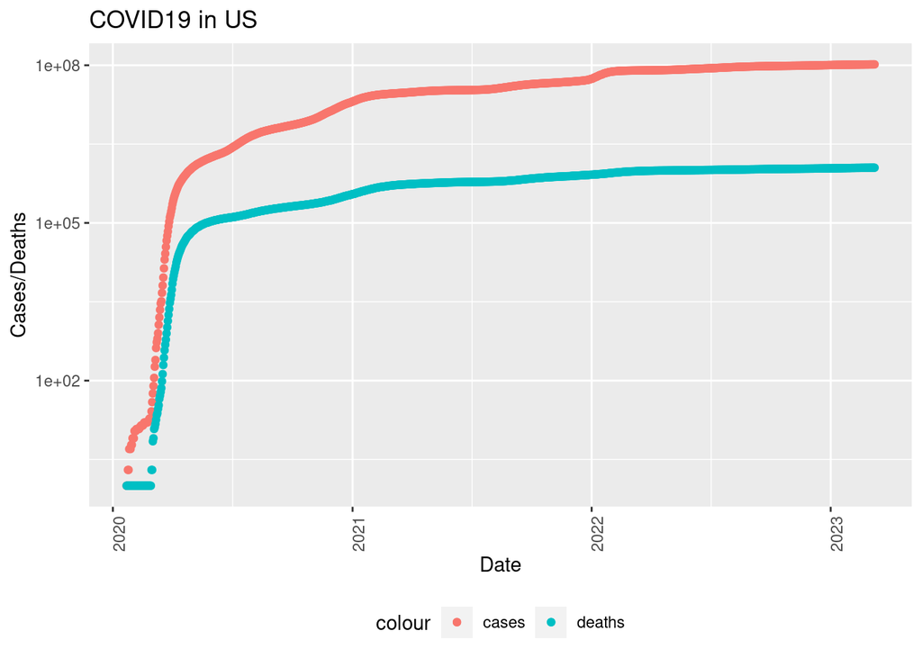

```r
US_totals %>%
  ggplot(aes(x = date, y = cases)) +
  geom_point(aes(color = "cases")) +
  geom_point(aes(y = deaths, color = "deaths")) +
  scale_y_log10() + theme(legend.position = "bottom", axis.text.x = element_text(angle = 90)) +
  labs(title = "COVID19 in US", x = "Date", y = "Cases/Deaths")
```

- We will now introduce additional variables to track the daily new cases and new deaths. These values will be calculated by subtracting the current number of deaths from the corresponding figure recorded one week prior. This specific choice of a one-week interval allows for a smoother graph representation.

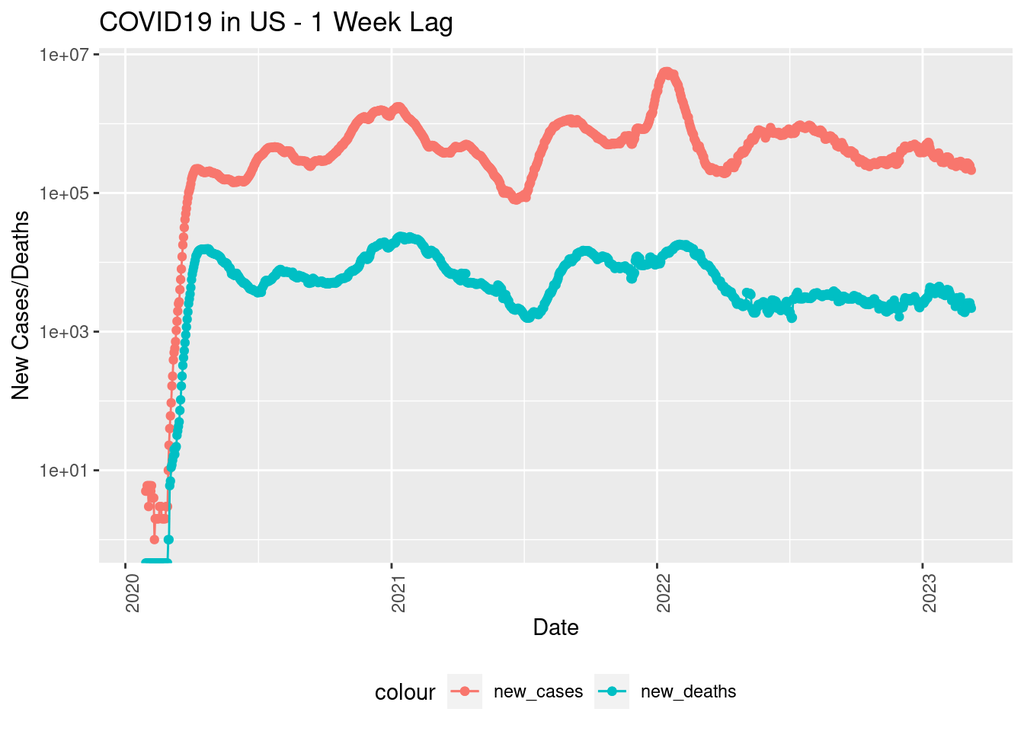

```r
lag_value = 7

US_totals <- US_totals %>%
  mutate(new_cases = cases - lag(cases, lag_value), new_deaths = deaths - lag(deaths, lag_value))

US_totals %>%
  ggplot(aes(x = date, y = new_cases)) +
  geom_line(aes(color = "new_cases")) +
  geom_point(aes(color = "new_cases")) +
  geom_line(aes(y = new_deaths, color = "new_deaths")) +
  geom_point(aes(y = new_deaths, color = "new_deaths")) +
  scale_y_log10() +
  theme(legend.position = "bottom", axis.text.x = element_text(angle = 90)) +
  labs(title = "COVID19 in US - 1 Week Lag", x = "Date", y = "New Cases/Deaths")
```

- Let’s now visualize the data with a 30-day lag.

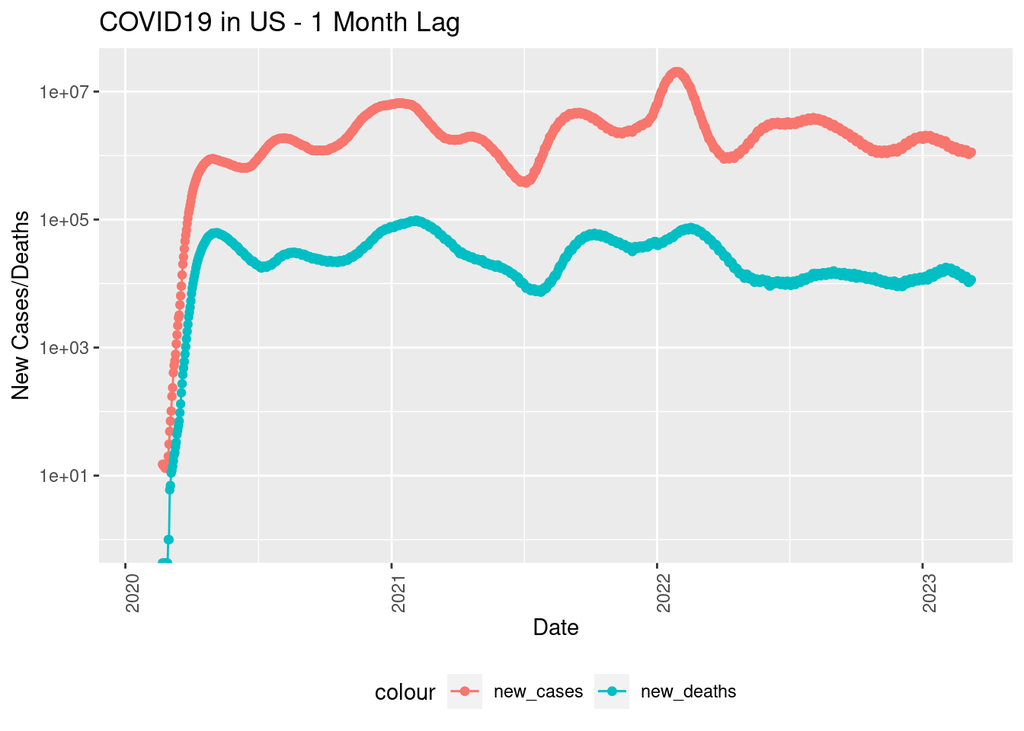

```r
lag_value = 30

US_totals <- US_totals %>%
  mutate(new_cases = cases - lag(cases, lag_value), new_deaths = deaths - lag(deaths, lag_value))

US_totals %>%
  ggplot(aes(x = date, y = new_cases)) +
  geom_line(aes(color = "new_cases")) +
  geom_point(aes(color = "new_cases")) +
  geom_line(aes(y = new_deaths, color = "new_deaths")) +
  geom_point(aes(y = new_deaths, color = "new_deaths")) +
  scale_y_log10() +
  theme(legend.position = "bottom", axis.text.x = element_text(angle = 90)) +
  labs(title = "COVID19 in US - 1 Month Lag", x = "Date", y = "New Cases/Deaths")
```

- Additionally, let’s explore the yearly increase, considering that we now have data spanning multiple years. We will examine the increase in cases per year. What I noticed in the graph below is that it looks like there is a substantial decrease in the number of deaths.

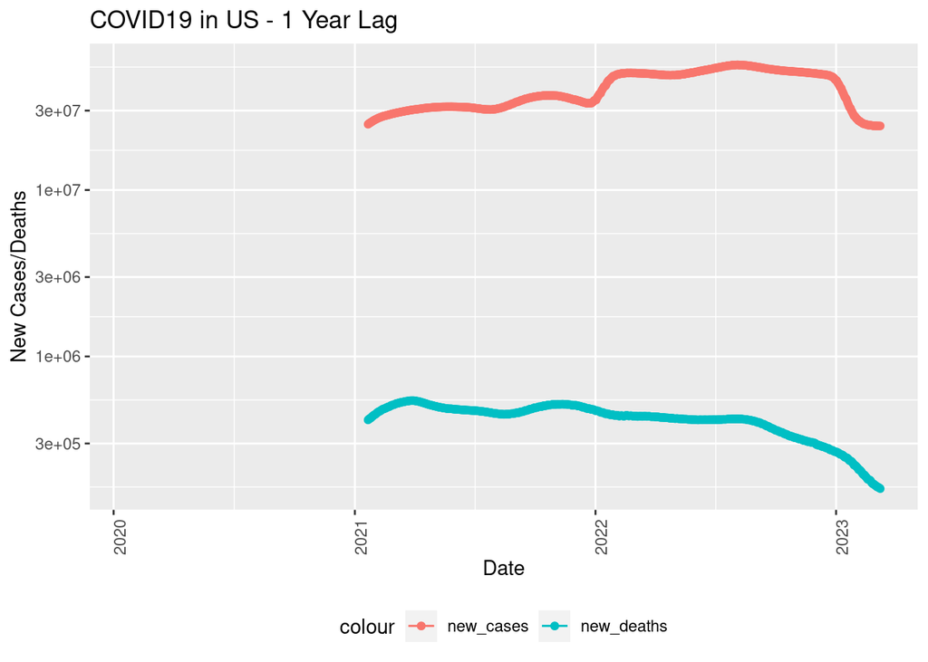

```r
lag_value = 365

US_by_state <- US_by_state %>%
  mutate(new_cases = cases - lag(cases, lag_value), new_deaths = deaths - lag(deaths, lag_value))

US_totals <- US_totals %>%
  mutate(new_cases = cases - lag(cases, lag_value), new_deaths = deaths - lag(deaths, lag_value))

US_totals %>%
  ggplot(aes(x = date, y = new_cases)) +
  geom_line(aes(color = "new_cases")) +
  geom_point(aes(color = "new_cases")) +
  geom_line(aes(y = new_deaths, color = "new_deaths")) +
  geom_point(aes(y = new_deaths, color = "new_deaths")) +
  scale_y_log10() +
  theme(legend.position = "bottom", axis.text.x = element_text(angle = 90)) +
  labs(title = "COVID19 in US - 1 Year Lag", x = "Date", y = "New Cases/Deaths")
```

- Now, let’s shift our focus to Washington state. As we examine the graphs below, we can see that Washington state is following the same overall trend as depicted earlier for the entire United States.

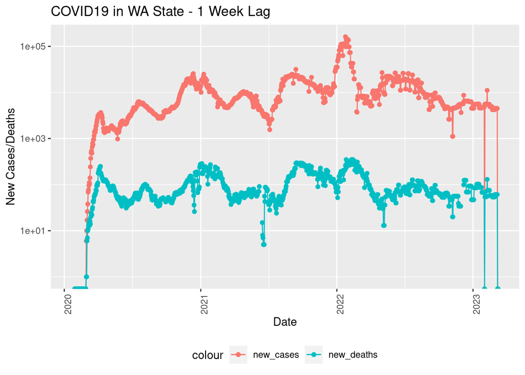

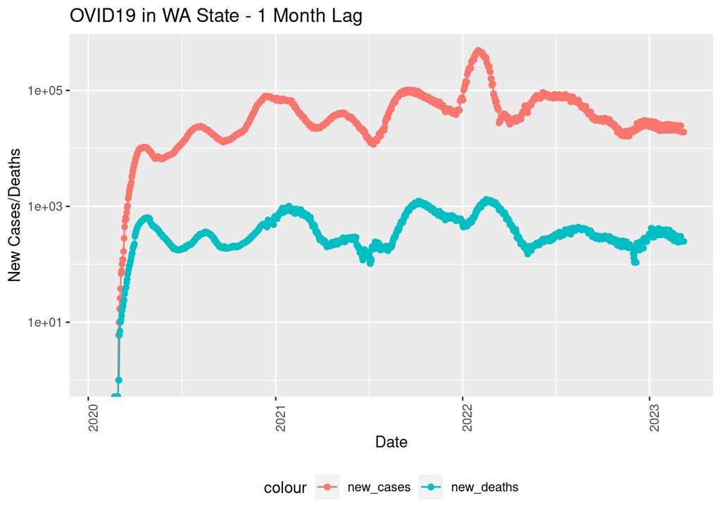

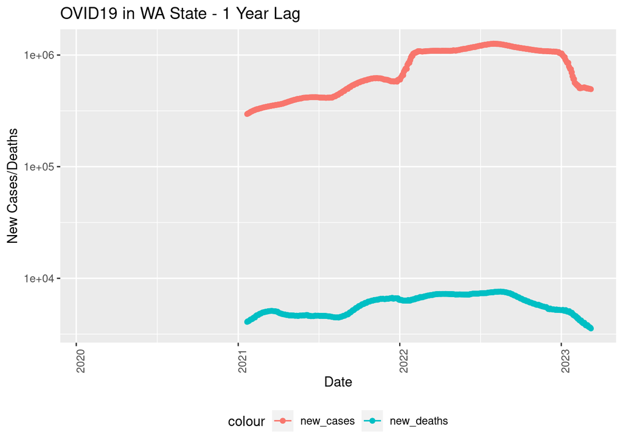

- Let’s proceed by grouping the counties and aggregating the number of cases. In addition, I’ll apply a filter to exclude some data from Washington state, such as “Unassigned” and “Out of WA,” as they seem to contain some missing data.

```r
# Filter Washington state only, and remove "Unassigned" and "Out of WA" data.
WA_state <- US %>%
  filter(Province_State == "Washington") %>%
  filter(Admin2 != "Unassigned") %>%
  filter(Admin2 != "Out of WA") %>%
  mutate(new_cases = cases - lag(cases), new_deaths = deaths - lag(deaths), death_rate = deaths/cases)

# Check the data.
tail(WA_state)
```

```
## # A tibble: 6 × 11
##   Admin2 Province_State Country_Region Combined_Key  date       cases Population
##   <chr>  <chr>          <chr>          <chr>         <date>     <dbl>      <dbl>
## 1 Yakima Washington     US             Yakima, Wash… 2023-03-04 83734     250873
## 2 Yakima Washington     US             Yakima, Wash… 2023-03-05 83734     250873
## 3 Yakima Washington     US             Yakima, Wash… 2023-03-06 83734     250873
## 4 Yakima Washington     US             Yakima, Wash… 2023-03-07 83734     250873
## 5 Yakima Washington     US             Yakima, Wash… 2023-03-08 83734     250873
## 6 Yakima Washington     US             Yakima, Wash… 2023-03-09 83734     250873
## # ℹ 4 more variables: deaths <dbl>, new_cases <dbl>, new_deaths <dbl>,
## #   death_rate <dbl>
```

```r
# Group by counties
WA_state_by_counties <- WA_state %>%
  group_by(Admin2) %>%
  summarize(total_cases = sum(cases),
            total_deaths = sum(deaths),
            Population = sum(Population),
            ) %>%
  ungroup()

# Print a summary of the data we have so far and make sure it's good
summary(WA_state)
```

```
##     Admin2          Province_State     Country_Region     Combined_Key
##  Length:44577       Length:44577       Length:44577       Length:44577
##  Class :character   Class :character   Class :character   Class :character
##  Mode  :character   Mode  :character   Mode  :character   Mode  :character
##
##
##
##
##       date                cases          Population          deaths
##  Min.   :2020-01-22   Min.   :     0   Min.   :   2225   Min.   :   0.0
##  1st Qu.:2020-11-02   1st Qu.:   437   1st Qu.:  22425   1st Qu.:   6.0
##  Median :2021-08-15   Median :  3463   Median :  66768   Median :  42.0
##  Mean   :2021-08-15   Mean   : 20702   Mean   : 195254   Mean   : 194.6
##  3rd Qu.:2022-05-28   3rd Qu.: 15105   3rd Qu.: 204390   3rd Qu.: 174.0
##  Max.   :2023-03-09   Max.   :549865   Max.   :2252782   Max.   :3512.0
##
##    new_cases           new_deaths          death_rate
##  Min.   :-549865.0   Min.   :-3512.000   Min.   :0.0000
##  1st Qu.:      0.0   1st Qu.:    0.000   1st Qu.:0.0080
##  Median :      0.0   Median :    0.000   Median :0.0113
##  Mean   :      1.9   Mean   :    0.019   Mean   :0.0146
##  3rd Qu.:     15.0   3rd Qu.:    0.000   3rd Qu.:0.0152
##  Max.   :  19214.0   Max.   :   45.000   Max.   :2.0000
##  NA's   :1           NA's   :1           NA's   :2230
```

```r
summary(WA_state_by_counties)
```

```
##     Admin2           total_cases         total_deaths       Population
##  Length:39          Min.   :   249039   Min.   :    935   Min.   :2.543e+06
##  Class :character   1st Qu.:  2176342   1st Qu.:  27812   1st Qu.:2.566e+07
##  Mode  :character   Median :  6996800   Median :  82129   Median :7.632e+07
##                     Mean   : 23663006   Mean   : 222468   Mean   :2.232e+08
##                     3rd Qu.: 21871165   3rd Qu.: 196412   3rd Qu.:1.906e+08
##                     Max.   :248811536   Max.   :2077113   Max.   :2.575e+09
```

- Let’s create a visualization by graphing the population and the total number of cases per county. This will provide a clear visual representation of how the cases are distributed across different counties based on their respective populations.

```r
# First we need to pivot the data so we can group the Population and the total cases together
WA_state_by_counties_pivoted <- WA_state_by_counties %>%
  pivot_longer(cols=c('total_cases', 'Population'), names_to='variable',
  values_to="value")

WA_state_by_counties_pivoted
```

```
## # A tibble: 78 × 4
##    Admin2  total_deaths variable        value
##    <chr>          <dbl> <chr>           <dbl>
##  1 Adams          28237 total_cases   3293622
##  2 Adams          28237 Population   22840569
##  3 Asotin         44704 total_cases   2835680
##  4 Asotin         44704 Population   25811226
##  5 Benton        335603 total_cases  33040240
##  6 Benton        335603 Population  233617770
##  7 Chelan        107028 total_cases  12740435
##  8 Chelan        107028 Population   88239600
##  9 Clallam        78786 total_cases   6689251
## 10 Clallam        78786 Population   88389333
## # ℹ 68 more rows
```

[figure not shown]

```r
# Graph both the total number of cases and deaths by county.
WA_state_by_counties_pivoted %>%
  ggplot(aes(fill=variable, x = Admin2, y = value)) +
  geom_bar(position="dodge", stat="identity") +
  theme(axis.text.x = element_text(angle = 90, vjust = 0.5, hjust=1)) +
  labs(title = "Cases/Deaths per county in Washington", x = "County", y = NULL)
```

- Next, we will proceed to display the infection rate per county and highlight the top 3 counties. This visualization allows us to identify the counties with the highest infection rates and gain insights into the distribution of COVID-19 cases across different regions.

```r
# Calulate the rate of infection
WA_state_by_counties <- WA_state_by_counties %>%
  mutate(infection_rate = total_cases * 100/ Population)

# Print the max infection rate to make sure mutate worked.
max(WA_state_by_counties$infection_rate)
```

```
## [1] 19.27053
```

```r
WA_state_by_counties_pivoted <- WA_state_by_counties %>%
  pivot_longer(cols=c('total_cases', 'infection_rate'), names_to='variable',
  values_to="value")

WA_state_by_counties_pivoted
```

```
## # A tibble: 78 × 5
##    Admin2  total_deaths Population variable             value
##    <chr>          <dbl>      <dbl> <chr>                <dbl>
##  1 Adams          28237   22840569 total_cases     3293622
##  2 Adams          28237   22840569 infection_rate       14.4
##  3 Asotin         44704   25811226 total_cases     2835680
##  4 Asotin         44704   25811226 infection_rate       11.0
##  5 Benton        335603  233617770 total_cases    33040240
##  6 Benton        335603  233617770 infection_rate       14.1
##  7 Chelan        107028   88239600 total_cases    12740435
##  8 Chelan        107028   88239600 infection_rate       14.4
##  9 Clallam        78786   88389333 total_cases     6689251
## 10 Clallam        78786   88389333 infection_rate        7.57
## # ℹ 68 more rows
```

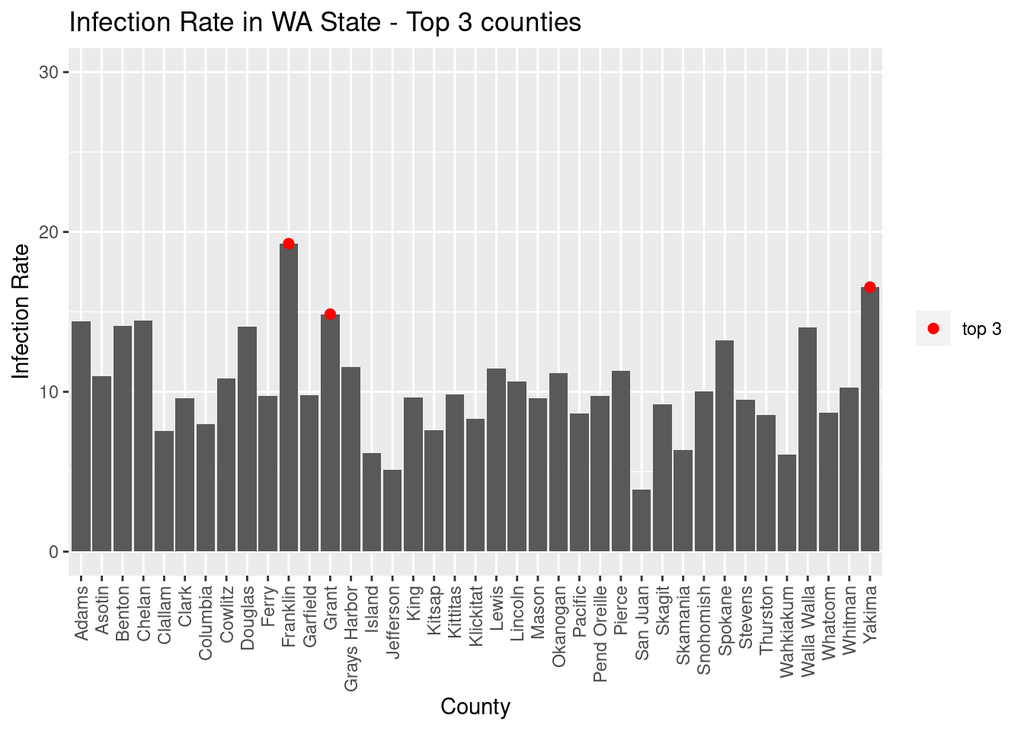

```r
top_3_counties <- WA_state_by_counties %>%
  arrange(desc(infection_rate)) %>%
  top_n(3, infection_rate)

WA_state_by_counties %>%
  arrange(WA_state_by_counties, desc(infection_rate)) %>%
  ggplot(aes(x = Admin2, y = infection_rate)) +
  geom_bar(stat="identity")  +
  geom_point(data = top_3_counties, aes(x = Admin2, y = infection_rate, color = "top 3"), size = 2) +
  scale_color_manual(name = "", values = c("top 3" = "red")) +
  theme(axis.text.x = element_text(angle = 90, vjust = 0.5, hjust=1)) +
  ylim(0, 30)+
  labs(title = "Infection Rate in WA State - Top 3 counties ", x = "County", y = "Infection Rate")
```

- To predict the number of COVID-19 deaths based on the reported cases, we will employ a linear regression model. By utilizing this linear model, we can predict the deaths based on the cases.

```r
# Let's see if we can predict the deaths per thousand
WA_state <- US %>%
  filter(Province_State == "Washington", cases > 0, Population > 0) %>%
  group_by(Admin2) %>%
  summarize(deaths = max(deaths),
            cases = max(cases),
            Population = max(Population),
            cases_per_thousand = cases * 1000 /Population,
            deaths_per_thousand = deaths * 1000 /Population,
            ) %>%
  ungroup()

WA_state
```

```
## # A tibble: 39 × 6
##    Admin2   deaths  cases Population cases_per_thousand deaths_per_thousand
##    <chr>     <dbl>  <dbl>      <dbl>              <dbl>               <dbl>
##  1 Adams        45   5647      19983               283.                2.25
##  2 Asotin       86   5606      22582               248.                3.81
##  3 Benton      539  62042     204390               304.                2.64
##  4 Chelan      196  24171      77200               313.                2.54
##  5 Clallam     209  15809      77331               204.                2.70
##  6 Clark      1047 111985     488241               229.                2.14
##  7 Columbia     18    751       3985               188.                4.52
##  8 Cowlitz     424  27341     110593               247.                3.83
##  9 Douglas      87  13333      43429               307.                2.00
## 10 Ferry        34   1825       7627               239.                4.46
## # ℹ 29 more rows
```

```r
# let's model the data
model <- lm(deaths_per_thousand ~ cases_per_thousand, data = WA_state)

summary(model)
```

```
##
## Call:
## lm(formula = deaths_per_thousand ~ cases_per_thousand, data = WA_state)
##
## Residuals:
##     Min      1Q  Median      3Q     Max
## -1.6549 -0.6804 -0.2842  0.6227  2.2245
##
## Coefficients:
##                    Estimate Std. Error t value Pr(>|t|)
## (Intercept)        1.262704   0.625170   2.020   0.0507 .
## cases_per_thousand 0.005464   0.002549   2.144   0.0387 *
## ---
## Signif. codes:  0 '***' 0.001 '**' 0.01 '*' 0.05 '.' 0.1 ' ' 1
##
## Residual standard error: 0.9021 on 37 degrees of freedom
## Multiple R-squared:  0.1105, Adjusted R-squared:  0.08644
## F-statistic: 4.595 on 1 and 37 DF,  p-value: 0.0387
```

```r
WA_state_with_predictions <- WA_state %>% mutate(pred=predict(model))

WA_state_with_predictions
```

```
## # A tibble: 39 × 7
##    Admin2  deaths  cases Population cases_per_thousand deaths_per_thousand  pred
##    <chr>    <dbl>  <dbl>      <dbl>              <dbl>               <dbl> <dbl>
##  1 Adams       45   5647      19983               283.                2.25  2.81
##  2 Asotin      86   5606      22582               248.                3.81  2.62
##  3 Benton     539  62042     204390               304.                2.64  2.92
##  4 Chelan     196  24171      77200               313.                2.54  2.97
##  5 Clallam    209  15809      77331               204.                2.70  2.38
##  6 Clark     1047 111985     488241               229.                2.14  2.52
##  7 Columb…     18    751       3985               188.                4.52  2.29
##  8 Cowlitz    424  27341     110593               247.                3.83  2.61
##  9 Douglas     87  13333      43429               307.                2.00  2.94
## 10 Ferry       34   1825       7627               239.                4.46  2.57
## # ℹ 29 more rows
```

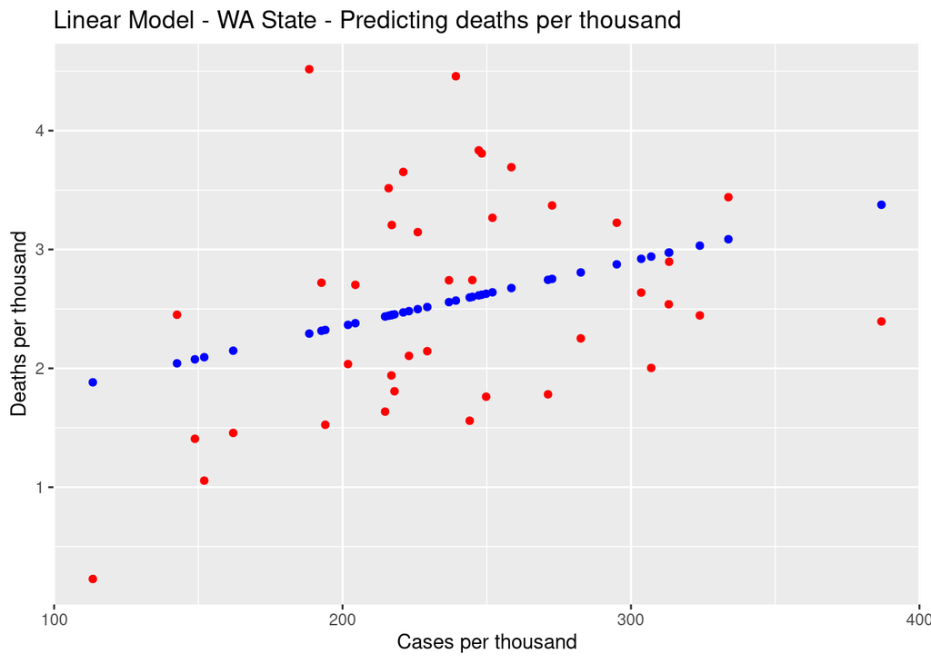

```r
WA_state_with_predictions %>%
  ggplot() +
  geom_point(aes(x = cases_per_thousand, y = deaths_per_thousand), color = "red") +
  geom_point(aes(x = cases_per_thousand, y = pred), color = "blue") +
  labs(title = "Linear Model - WA State - Predicting deaths per thousand", x = "Cases per thousand", y = "Deaths per thousand")
```

## Bias

1- It is crucial to approach the analysis of such data/reports with caution, as they can be subject to various biases. Questions arise regarding the data collection process, such as who is responsible for gathering the data and whether there are established data compliance protocols in place. Are the reported deaths accurately documented across all counties? Additionally, we must consider the accuracy of data entry and potential inconsistencies. If certain groups, counties, or regions are systematically favored in the data collection process, sampling bias can be introduced. Similarly, selective reporting of data can introduce reporting bias, impacting the overall analysis.

2- Another important consideration is to focus on rates rather than absolute numbers. Comparing the number of cases or deaths between different regions or counties without considering the infection or death rates can lead to erroneous conclusions. It is essential to assess the rate of infection and/or deaths to make informed decisions and avoid misinterpretations based solely on the raw numbers.

3- A personal bias might also affect how we analyze the data, for example, my political beliefs might influence my analysis, another one is confirmation bias, where we selectively focus on information that aligns with our beliefs.

We need to be aware of our biases so that we can avoid them and provide an objective analysis.